# IMS3.3

Ariana Kim

2023-08-08

# Background

## Research Question

Can correcting be used as a friendship cue within children?

## Study Design

Between-Subjects Design

**Predictors:** 1. Reported Age in Years: 4 to 12

2. Correcting vs. Affirmation:1=affirming, 2=correcting
- Categorical

**Outcome:** 1. Public vs. Private Selections: 0=public-1=private + Categorical

## Predicted Results

Correcting Condition: The main character would be better friends with the person corrected in private.

Affirming Condition: The main character would be better friends with the person affirmed in public.

Children’s Age: Older children (7-12) will be better at making these inferences compared to younger children (4-6).

# Data Preparation

## Load Data

```r
data<-read.csv("IMS3.3/IMS3.3 (Pre-Reg) Data - Sheet1.csv")
```

## Rename Variables

```r
colnames(data)[6]<-"condition"

colnames(data)[8]<-"corrected_in_public"

colnames(data)[9]<-"corrected_in_private"

colnames(data)[17]<-"friendship_choice"

colnames(data)[23]<-"age"

data<-subset(data,data$condition %in% c("R","W"))

data<-subset(data,data$age>=4)
data<-subset(data,data$age<13)

data <- data %>%
  filter(data$Exclude. == "No")
```

# Data Analysis

```r
data$choice<-(ifelse(data$friendship_choice==data$corrected_in_public, 0,1))

# Output Linear Regression

choiceIMS3.3<-glm(choice~condition*age,
                  data=data, family="binomial")

summary(choiceIMS3.3)
```

```
##
## Call:
## glm(formula = choice ~ condition * age, family = "binomial",
##     data = data)
##
## Coefficients:
##                Estimate Std. Error z value Pr(>|z|)
## (Intercept)      2.3570     0.7258   3.248 0.001164 **
## conditionW      -3.6437     1.0483  -3.476 0.000510 ***
## age             -0.3721     0.1018  -3.655 0.000257 ***
## conditionW:age   0.7402     0.1546   4.787  1.7e-06 ***
## ---
## Signif. codes:  0 '***' 0.001 '**' 0.01 '*' 0.05 '.' 0.1 ' ' 1
##
## (Dispersion parameter for binomial family taken to be 1)
##
##     Null deviance: 329.53  on 243  degrees of freedom
## Residual deviance: 273.92  on 240  degrees of freedom
## AIC: 281.92
##
## Number of Fisher Scoring iterations: 4
```

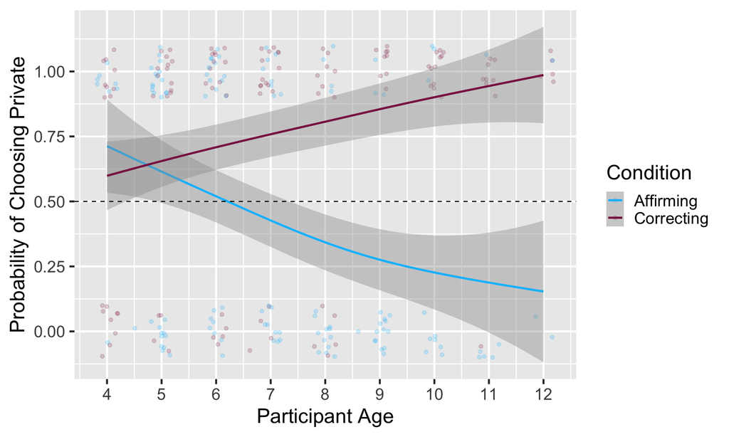

```r
plot<-ggplot(data=data,
              aes(x=age,
                  y=choice,
                  color=condition))+
  labs(x="Participant Age",
       y="Probability of Choosing Private",
       color="Condition")+
  geom_jitter(alpha=.2,height=.1)+
  geom_smooth(method="gam")+
  scale_color_manual(values=c("deepskyblue","violetred4"),labels=c("Affirming","Correcting"))+
  theme_gray(base_size=20)+
  geom_hline(yintercept=.5,linetype="dashed")+
  scale_x_continuous(breaks=4:12)

plot
```

## Analysis and Inferences

Correcting Condition: As the age demographic increases, the purple regression line showcases that children believed Alex was better friends with the character corrected in private.

Affirming Condition: As the age demographic increases, the blue regression line showcases that children believed Alex was better friends with the character affirmed in public.

As we can see, our hypothesis was supported. Children thought Alex would be better friends with the person corrected in private, and better friends with the person affirmed in public.